# homework

Junfeng Zhao

2021-12-17

## Question

Go through “R for Beginners” if you are not familiar with R programming.

Use knitr to produce at least 3 examples (texts, figures,tables).

## Answer

example 1：

$$y_i=\beta_0+\beta_1x_i$$

example 2:

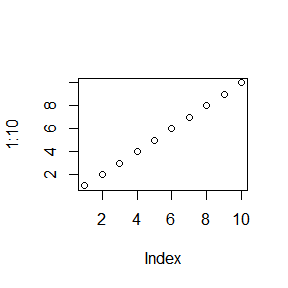

```r
plot(1:10)
```

example 3:

```r
x<-1:10;
y<-x^2;
lmr<-lm(y~x);
co<-summary(lmr)$coefficients;
print(co);
```

```
##             Estimate Std. Error   t value     Pr(>|t|)
## (Intercept)      -22  5.5497748 -3.964125 4.152962e-03
## x                 11  0.8944272 12.298374 1.777539e-06
```

```r
knitr::kable(co,digits=2,align = 'c')
```

|  | Estimate | Std. Error | t value | Pr(>\|t\|) |
| --- | --- | --- | --- | --- |
| (Intercept) | -22 | 5.55 | -3.96 | 0 |
| x | 11 | 0.89 | 12.30 | 0 |

example 4:

| x | y |
| --- | --- |
| 1 | 2 |
| 3 | 4 |

## Question

3.4: The Rayleigh density is
$$f(x)=\frac{x}{σ^2}e^{-x^2/(2σ^2)},x\geq0,σ>0.$$
Develop an algorithm to generate random samples from a Rayleigh(σ) distribution. Generate Rayleigh(σ) samples for several choices of σ > 0 and check that the mode of the generated samples is close to the theoretical mode σ(check the histogram).

3.11： Generate a random sample of size 1000 from a normal location mixture. The components of the mixture have N(0,1) and N(3,1) distributions with mixing probabilities p1 and p2=1−p1.Graph the histogram of the sample with density superimposed, for p1 = 0.75. Repeat with different values for p1 and observe whether the empirical distribution of the mixture appears to be bimodal. Make a conjecture about the values of p1 that produce bimodal mixtures.

3.20： A compound Poisson process is a stochastic process ${X(t),t≥0}$ that can be represented as the random sum $X(t)=\sum_{i=1}^{N(t)}Y_i,t\geq0$, where ${N(t),t≥0}$ is a Poisson process and Y1, Y2,… are iid and independent of {N(t), t≥0}.Write a program to simulate a compound Poisson(λ)–Gamma process (Y has a Gamma distribution). Estimate the mean and the variance of X(10) for several choices of the parameters and compare with the theoretical values. Hint: Show that $E[X(t)] = λtE[Y_1]$ and $Var(X(t)) = λtE[Y_1^2]$.

## Answer

3.4:

The algorithm to generate random samples from a Rayleigh(σ) distribution.

```r
Rayleigh<- function(n,σ){
r<- sqrt((-2)*(σ^2)*log(1-runif(n)))
return (r)
}
```

when $\sigma$=1

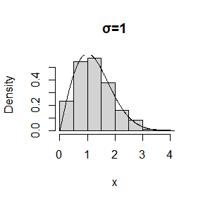

```r
σ=1
x<-Rayleigh(1000,σ)
hist(x, prob = TRUE, main = "σ=1")
y=seq(0,10,.01)
lines(y,(y/σ^2)*exp(-(y^2)/(2*σ^2)) )
```

when $\sigma$=2

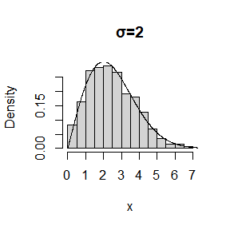

```r
σ=2
x<-Rayleigh(1000,σ)
hist(x, prob = TRUE, main = "σ=2")
y=seq(0,10,.01)
lines(y,(y/σ^2)*exp(-(y^2)/(2*σ^2)) )
```

3.11:

Develop an algorithm to generate a random sample of size 1000 from a normal location mixture.

```r
library(MASS)
loc.mix <- function(n, p, mu1, mu2, Sigma) {
n1 <- rbinom(1, size = n, prob = p)
n2 <- n - n1
x1 <- mvrnorm(n1, mu = mu1, Sigma)
x2 <- mvrnorm(n2, mu = mu2, Sigma)
X <- rbind(x1, x2)
return(X[sample(1:n), ])
}
```

when p=0.75:

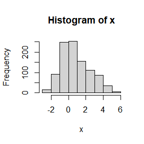

```r
x <- loc.mix(1000, .75, 0, 3, Sigma =1)
r <- range(x) * 1.2
hist(x)
```

then,repeat p=0.05,p=0.25,p=0.5,p=0.95:

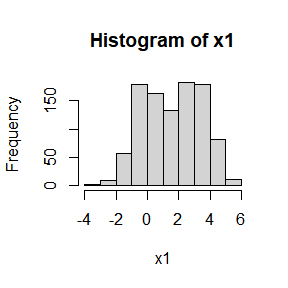

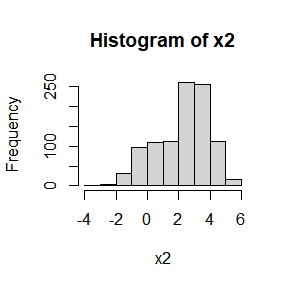

```r
x1<- loc.mix(1000, .5, 0, 3, Sigma =1)
x2<- loc.mix(1000, .25, 0, 3, Sigma =1)
x3<- loc.mix(1000, .95, 0, 3, Sigma =1)
x4<- loc.mix(1000, .05, 0, 3, Sigma =1)
#par(mfrow = c(2, 2))
hist(x1);hist(x2)
```

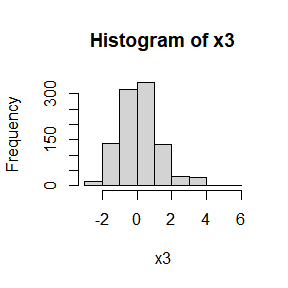

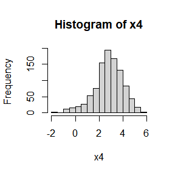

```r
hist(x3);hist(x4)
```

```r
par(mfrow = c(1, 1))
```

Obviously, the p may be 0.5.

3.20:

Write a program to simulate a compound Poisson(λ)–Gamma process (Y has a Gamma distribution):

```r
PG<-function(n,r,beta,lambda,t){
     Y<-matrix(0,n,1)
     for (i in 1:n) {
           k=rpois(1,t*lambda)
           X<-rgamma(k,shape=r,rate=beta)
           Y[i,]<-sum(X)
     }
     return(Y)
}
```

Estimate the mean and the variance of X(10) for several choices of the parameters and compare with the theoretical values:so t=10

when $\gamma=\beta=\lambda=1$

the theoretical values:

$E[X(t)] = λtE[Y_1]=λt\frac{\gamma}{\beta}=10$

$Var(X(t)) = λtE[Y_1^2]=λt\frac{\gamma(1+\gamma)}{\beta^2}=20$

the estimated values:

```r
x=PG(1000,1,1,1,10)
mean(x);var(x)
```

```
## [1] 10.16818
```

```
##          [,1]
## [1,] 21.03504
```

when $\gamma=\beta=\lambda=2$

the theoretical values:

$E[X(t)] =λtE[Y_1]=λt\frac{\gamma}{\beta}=20$

$Var(X(t)) = λtE[Y_1^2]=λt\frac{\gamma(1+\gamma)}{\beta^2}=30$

the estimated values:

```r
x=PG(1000,2,2,2,10)
mean(x);var(x)
```

```
## [1] 19.94785
```

```
##          [,1]
## [1,] 27.66391
```

## Question

5.4

Write a function to compute a Monte Carlo estimate of the $Beta(3,3)$ cdf,and use the function to estimate $F(x)$ for $x = 0.1, 0.2,..., 0.9.$ Compare the estimates with the values returned by the pbeta function in R.

5.9

The Rayleigh density is
$$f(x)=\frac{x}{σ^2}e^{-x^2/(2σ^2)}, x\geq0,σ>0$$
Implement a function to generate samples from a Rayleigh(σ) distribution,using antithetic variables. What is the percent reduction in variance of $X+X'\over2$ compared with $X1+X2\over2$ for independent $X1, X2$?

5.13

Find two importance functions $f_1$ and $f_2$ that are supported on $(1,∞)$ and are ‘close’ to
$$g(x) = \frac{x^2}{\sqrt{2\pi}}e^{−x^2/2}, x>1.$$
Which of your two importance functions should produce the smaller variance in estimating
$$\int_{1}^{\infty}{\frac{x^2}{\sqrt{2\pi}}e^{−x^2/2}}dx$$
by importance sampling? Explain.

5.14

Obtain a Monte Carlo estimate of
$$\int_{1}^{\infty}{\frac{x^2}{\sqrt{2\pi}}e^{−x^2/2}}dx$$
by importance sampling.

## Answer

5.4:

The $beta(3,3)$ cdf is
$$F(x)=\int_{0}^{x}{30t^2(1-t)^2}dt$$
Making the substitution $y=t/x$, we have $dt=xdy$ and
$$\theta=\int_{0}^{1}{30x^3y^2(1-xy)^2}dy$$
Thus, $\theta=E_Y[30x^3y^2(1-xy)^2]$, where the random variable Y has the Uniform(0,1) distribution.

```r
x<-seq(.1,.9,length=9)
u<-runif(10000)
cdf<-numeric(length(x))
for (i in 1:length(x)) {
      g<-30*x[i]^3*u^2*(1-x[i]*u)^2
      cdf[i]<-mean(g)
}
Phi<-pbeta(x,3,3)
print(round(rbind(x,cdf,Phi),3))
```

```
##      [,1]  [,2]  [,3]  [,4] [,5]  [,6]  [,7]  [,8]  [,9]
## x   0.100 0.200 0.300 0.400  0.5 0.600 0.700 0.800 0.900
## cdf 0.009 0.058 0.163 0.317  0.5 0.684 0.839 0.946 0.997
## Phi 0.009 0.058 0.163 0.317  0.5 0.683 0.837 0.942 0.991
```

5.9:

Derive the inverse function
$$F_X^{-1}(u)=\sqrt{-2\sigma^2\ln(1-u)}$$
and U ∼ Uniform(0,1), Note that if U is uniformly distributed on (0, 1) then 1−U has the same distribution as U, but U and 1 − U are negatively correlated. Then in
$$F_X^{-1}(u)=\sqrt{-2\sigma^2\ln(1-u)}$$
has the same distribution as
$$F_X^{-1}(1-u)=\sqrt{-2\sigma^2\ln(u)}$$
Implement a function to generate samples from a Rayleigh(σ) distribution, using antithetic variables.

then,we can get $X,X'$,where $\sigma=1$:

```r
Rayleigh<- function(n,σ){
        u<- runif(n)
        X_a<- sqrt((-2)*(σ^2)*log(u))
        X<-sqrt((-2)*(σ^2)*log(1-u))
    return(list(X,X_a))
}
Y<-Rayleigh(100000,1)
Z<-matrix(unlist(Y),100000,2)
X<-Z[,1]
X_a<-Z[,2]
```

and derive $X_1 ,X_2$:

```r
Rayleigh2<- function(n,σ){
t<- sqrt((-2)*(σ^2)*log(1-runif(n)))
return (t)
}
X1<-Rayleigh2(100000,1)
X2<-Rayleigh2(100000,1)
```

the percent reduction in variance of $X+X'\over2$ compared with $X1+X2\over2$ for independent $X1, X2$ :

```r
Y1<-var((X1+X2)/2)
Y2<-var((X+X_a)/2)
print((Y1-Y2)/Y1)
```

```
## [1] 0.94738
```

5.13:

```r
m<- 10000
g<-function(x){x^2/sqrt(2*pi)*exp(-x^2/2)*(x>1)}


x<-rnorm(m,1.5,1)
g1<-g(x)/dnorm(x,1.5,1)
theta.hat1<-mean(g1)


x<-rgamma(m,4.5,2.5)
g2<-g(x)/dgamma(x,4.5,2.5)
theta.hat2<-mean(g2)

print(c(theta.hat1,theta.hat2))
```

```
## [1] 0.4015175 0.4006390
```

```r
integrate(g,1,Inf)
```

```
## 0.400626 with absolute error < 5.7e-07
```

```r
print(c(sd(g1),sd(g2)))
```

```
## [1] 0.3027036 0.2146818
```

The second important function is better, the estimate is closer to the theoretical value with a smaller variance.

5.14:

```r
m<- 10000
f<-function(x){x^2/sqrt(2*pi)*exp(-x^2/2)*(x>1)}

x<-rgamma(m,4.5,2.5)
f1<-f(x)/dgamma(x,4.5,2.5)
theta.hat1<-mean(f1)

print(c(theta.hat1,sd(f1)))
```

```
## [1] 0.4031241 0.2130849
```

```r
integrate(f,1,Inf)
```

```
## 0.400626 with absolute error < 5.7e-07
```

The estimated value is 0.4031241

## Question

**6.5.** Suppose a $95\%$ symmetric t-interval is applied to estimate a mean, but the sample data are non-normal. Then the probability that the confidence interval covers the mean is not necessarily equal to 0.95. Use a Monte Carlo experiment to estimate the coverage probability of the t-interval for random samples of $\chi^2(2)$ data with sample size n = 20. Compare your t-interval results with the simulation results in Example 6.4. (The t-interval should be more robust to departures from normality than the interval for variance.)

**6.A** Use Monte Carlo simulation to investigate whether the empirical Type I error rate of the t-test is approximately equal to the nominal significance level $\alpha$, when the sampled population is non-normal. The t-test is robust to mild departures from normality. Discuss the simulation results for the cases where the sampled population is (i) $\chi^2(1)$, (ii) Uniform(0,2), and (iii) Exponential(rate=1). In each case, test $H_0 : \mu = \mu_0~vs~H_1 : \mu \not= \mu_0$, where µ0 is the mean of $\chi^2(1)$, Uniform(0,2), and Exponential(1), respectively.

**3.**If we obtain the powers for two methods under a particular simulation setting with 10,000 experiments: say, 0.651 for one method and 0.676 for another method. We want to know if the powers are different at 0.05 level.

(1)What is the corresponding hypothesis test problem?

(2)What test should we use? Z-test, two-sample t-test, paired-t test or McNemar test? Why?

(3)Please provide the least necessary information for hypothesis testing.

## Answer

**6.5**

The t-interval for the mean of a population is:
$$(\bar{x}-t_{\frac{\alpha}{2}}(n-1)\cdot\frac{S}{\sqrt{n}},\bar{x}+t_{\frac{\alpha}{2}}(n-1)\cdot\frac{S}{\sqrt{n}})$$
where $S$ is the sample standard deviation,$\bar{x}$ is the mean of sample, $t_{\frac{\alpha}{2}}(n-1)$ is the upper $\frac{\alpha}{2}$-quantile of $t$ distribution with $df=n-1$.

The population is known that $X\sim \chi^2(2)$ and $\theta=E(X)=2$. Therefore, the empirical estimate of the confidence level is
$$\hat{P}=\frac{1}{m} \sum\limits_{j=1}^m I(\hat{\theta}_1^{(j)}<\theta<\hat{\theta}_2^{(j)})$$
where $(\hat{\theta}_1^{(j)},\hat{\theta}_2^{(j)})$ is the confidence interval $C_j$ for the $j^{th}$ sample.

```r
set.seed(1000)
n<-20
alpha<-0.05
CI<-replicate(1000,expr={
      x<-rchisq(n,df=2)
      CI_1<-mean(x)+sqrt(var(x)/n)*qt(alpha/2,df=n-1)
      CI_2<-mean(x)-sqrt(var(x)/n)*qt(alpha/2,df=n-1)
      return(c(CI_1,CI_2))
})
mean(CI[1,]<2&CI[2,]>2)
```

```
## [1] 0.932
```

The estimate of the coverage probability of the t-interval is 0.932,which is smaller than 0.95.However,compared with simulation results in Example 6.4,the t-interval should be more robust to departures from normality than the interval for variance.

**6.A**

```r
set.seed(100)
n<-20;alpha<- .05;mu0<-1
m<-10000
p_1<-p_2<-p_3<-numeric(m)
for(j in 1:m){
x<-rchisq(n,df=1)
ttest_1<-t.test(x,alternative="two.sided",mu=mu0)
p_1[j]<-ttest_1$p.value
y<-runif(n,0,2)
ttest_2<-t.test(y,alternative="two.sided",mu=mu0)
p_2[j]<-ttest_2$p.value
z<-rexp(n,1)
ttest_3<-t.test(z,alternative="two.sided",mu=mu0)
p_3[j]<-ttest_3$p.value
}
p_1.hat<-mean(p_1<alpha)
p_2.hat<-mean(p_2<alpha)
p_3.hat<-mean(p_3<alpha)
print(c(p_1.hat,p_2.hat,p_3.hat))
```

```
## [1] 0.0992 0.0498 0.0831
```

**3.**

(1)the corresponding hypothesis test problem is

$$H_0:power_1 = power_2 \qquad H_1:power_1 \ne power_2$$

(2)I think we should use **paired-t test**.

Because firstly, the two methods are independent,so Z-test can not be used. Secondly, since the sample of two methods are not independent, we can not use two-sample t test as well. thirdly, we just have a property, which are not suitable for McNemar test.

(3)It needs to know the relationship between the two methods.

## Exercise 6.C

Repeat Examples 6.8 and 6.10 for Mardia’s multivariate skewness test. Mardia [187] proposed tests of multivariate normality based on multivariate generalizations of skewness and kurtosis. If $X$and $Y$ are iid, the multivariate population skewness $\beta_{1,d}$ is defined by Mardia as
$$\beta_{1,d} = E [ (X − \mu)^T \Sigma^{-1}(Y − \mu)]^ 3 .$$
Under normality, $\beta_{1,d} = 0$. The multivariate skewness statistic is
$$b_{1,d} =\frac{1}{n^2} \displaystyle \sum^{n}_{i,j=1}{((X_i − \bar{X})^T\hat{\Sigma}^{−1}(X_j − \bar{X}))^3},\tag{6.5}$$
where $\hat{\Sigma}$ is the maximum likelihood estimator of covariance. Large values of $b_{1,d}$ are significant. The asymptotic distribution of $nb_{1,d}/6$ is chisquared with $d(d + 1)(d + 2)/6$ degrees of freedom.

### Solution

**Example 6.8**

Let d is 3.

```r
library(MASS)

set.seed(21068)
d<-3
mu=c(0,0,0)
sigma=matrix(c(1,0,0,0,4,0,0,0,9),3,3)
m=1000
n=c(10, 20, 30, 50, 100, 500)
cv<-qchisq(0.95,d*(d+1)*(d+2)/6)  #卡方分布的下0.95分位点

sk<-function(x){
    n<-nrow(x)
    d<-ncol(x)
    xcen<-matrix(0,n,d)
    for(i in 1:d){
       xcen[,i]<-x[,i]-mean(x[,i])
    }
    Sigma.hat<-t(xcen)%*%xcen/n    #Sigma的估计
    y<-xcen%*%solve(Sigma.hat)%*%t(xcen)
    z<-sum(colSums(y^{3}))/(n*n)   #b1,d 的值
    test<-n*z/6                    #nb/6
    return(test)
}

p.reject=numeric(length(n))
for(i in 1:length(n)) {
    sktests<-numeric(m)
    for (j in 1:m) {
       x=mvrnorm(n[i],mu,sigma)
       sktests[j]<-as.integer(abs(sk(x))>=cv)  #检验决策 比较二者大小
    }
    p.reject[i]<-mean(sktests)
}

rbind(n,cv,p.reject)
```

```
##              [,1]     [,2]     [,3]     [,4]      [,5]      [,6]
## n        10.00000 20.00000 30.00000 50.00000 100.00000 500.00000
## cv       18.30704 18.30704 18.30704 18.30704  18.30704  18.30704
## p.reject  0.00100  0.02100  0.03800  0.04400   0.04500   0.04400
```

Mardia’s multivariate skewness test also has the problem that when the sample size is small, it tends to underestimates the Type-1 error.

**Example 6.10**

Choose $d=2$ and calculate the power with different $\epsilon$ .The contaminated multivariate normal distribution is denoted by:
$$(1-\epsilon)N(0,0;1,1;0)+\epsilon N(0,0;100,100;0),~~~~0\le \epsilon \le 1$$

In this case the significance level $\alpha=0.1$ and the sample size $n=30$.

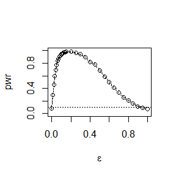

```r
library(MASS)

set.seed(21068)
alpha <- .1
n <- 30;d<-2
m <- 2000;mu<-c(0,0)
epsilon <- c(seq(0, .15, .01), seq(.15, 1, .05))
N <- length(epsilon)
pwr <- numeric(N)
cv <- qchisq(.9,d*(d+1)*(d+2)/6)
x <- matrix(0,n,d)

for (j in 1:N) {
   e <- epsilon[j]
   sktests <- numeric(m)
   for (i in 1:m) {
      sigma <- sample(c(1, 100), replace = TRUE,size = n, prob = c(1-e, e))
      for (k in 1:n) {
         x[k,]=mvrnorm(1, mu, sigma[k]*diag(2))
      }
         sktests[i] <- as.integer(abs(sk(x))>= cv )
    }
    pwr[j] <- mean(sktests)
}

plot(epsilon, pwr, type = "b",
        xlab = bquote(epsilon), ylim = c(0,1))
abline(h = .1, lty = 3)
se <- sqrt(pwr * (1-pwr) / m)
lines(epsilon, pwr+se, lty = 3)
lines(epsilon, pwr-se, lty = 3)
```

From the result and the figure we can easily find that when the epsilon value is close to 0 or 1, the empirical power is close to 0.1. Also, the power is close to 1 when epsilon is about 0.2. As epsilon value increasing, the empirical power increases steadily and decreases slowly.

## Exercise 7.7

Refer to Exercise $7.6$. Efron and Tibshirani discuss the following example [84,Ch.7]. The five-dimensional scores data have a $5×5$ covariance matrix $\Sigma$,with positive eigenvalues $\lambda_1>\lambda_2>\lambda_3>\lambda_4>\lambda_5$. In principal components analysis,
$$\theta = \frac{\lambda_1}{\sum_{j=1}^{5}{\lambda_j}}$$
measures the proportion of variance explained by the first principal component. Let $\hat{\lambda}_1>\hat{\lambda}_2>\hat{\lambda}_3>\hat{\lambda}_4>\hat{\lambda}_5$ be the eigenvalues of $\hat{\Sigma}$, where $\hat{\Sigma}$ is the MLE of $\Sigma$. Compute the sample estimate
$$\hat{\theta} = \frac{\hat{\lambda}_1}{\sum_{j=1}^{5}{\hat{\lambda}_j}}$$
$$Bootstrap ~~and ~~Jackknife \tag{213}$$
of $\theta$. Use bootstrap to estimate the bias and standard error of $\hat{\theta}$.

### Solution

```r
library(bootstrap)
data(scor,package = "bootstrap")

n <- nrow(scor)
X <- cov(scor)
Y <- eigen(X)$value
theta.hat <- Y[1]/sum(Y)

B <- 200
scor.b <- matrix(0, 88, 5)
theta.boot <- numeric(B)
for (b in 1:B) {
  i <- sample(1:n, size = n, replace = T)
  scor.b[,1] <- scor$mec[i]
  scor.b[,2] <- scor$vec[i]
  scor.b[,3] <- scor$alg[i]
  scor.b[,4] <- scor$ana[i]
  scor.b[,5] <- scor$sta[i]
  z <- eigen(cov(scor.b))$value
  theta.boot[b] <- z[1]/sum(z)
}

bias.boot <- mean(theta.boot) - theta.hat
se.boot <- sd(theta.boot)
print(c(bias.boot,se.boot))
```

```
## [1] 0.004835489 0.049610082
```

## Exercise 7.8

Refer to Exercise $7.7$. Obtain the jackknife estimates of bias and standard error of $\hat{\theta}$.

### Solution

```r
library(bootstrap)
data(scor,package = "bootstrap")

n <- nrow(scor)
X <- cov(scor)
Y <- eigen(X)$value
theta.hat <- Y[1]/sum(Y)

theta.jack <- numeric(n)
for (i in 1:n) {
   Z <-   eigen(cov(scor[-i,]))$value
   theta.jack[i] <- Z[1]/sum(Z)
}

bias.jack <- (n-1)*(mean(theta.jack)-theta.hat)
se.jack <- sqrt((n-1) * mean((theta.jack - mean(theta.jack))^2))
print(c(bias.jack,se.jack))
```

```
## [1] 0.001069139 0.049552307
```

## Exercise 7.9

Refer to Exercise $7.7$. Compute 95% percentile and BCa confidence intervals for $\hat{\theta}$.

### Solution

```r
library(boot)
data(scor,package = "bootstrap")

theta.b <- function(data,indices) {
  a <- data[indices,]
  b <- eigen(cov(a))$value
  b[1]/sum(b)
}

boot.obj <- boot(data = scor, statistic = theta.b, R=200)
ci <- boot.ci(boot.obj, type = c("perc", "bca"))
cat("Percentile CI:", paste0("(",paste(ci$percent[4:5], collapse=", "),")"), "\n")
```

```
## Percentile CI: (0.514731764997507, 0.719744777411498)
```

```r
cat("BCa CI:", paste0("(",paste(ci$bca[4:5], collapse=", "),")"), "\n")
```

```
## BCa CI: (0.513085631931562, 0.71524181641282)
```

## Exercise 7.B

Repeat Project $7.A$ for the sample skewness statistic. Compare the coverage rates for normal populations (skewness $0$) and $\chi^2(5)$ distributions (positive skewness).

### Solution

**normal population**

We set the normal populations is $N(0,1).$The skewness is $0$.

```r
library(boot)
set.seed(123)
m <- 1000
n <- 100
sk <- 0

boot.sk <- function(data, indices) {
     d <- data[indices]
     n <- length(d)
     e <- sum((d-mean(d))^3)/n
     f <- (sum((d-mean(d))^2)/n)^(3/2)
     return(e/f)
}

ci.norm <- ci.basic <- ci.perc <- matrix(NA,m,2)
for (i in 1:m) {
   U <- rnorm(n, 0, 1)
   de <- boot(data = U, statistic = boot.sk, R = 1000)
   ci <- boot.ci(de, type = c("norm", "basic", "perc"))
   ci.norm[i,] <- ci$norm[2:3]
   ci.basic[i,] <- ci$basic[4:5]
   ci.perc[i,] <- ci$percent[4:5]
}

rbind(distribution=c('norm', 'basic', 'perc'),
         ci_est=c(mean(ci.norm[,1] <= sk & ci.norm[,2] >= sk),
            mean(ci.basic[,1] <= sk & ci.basic[,2] >= sk),
            mean(ci.perc[,1] <= sk & ci.perc[,2] >= sk)),
         ci_leftmiss=c(mean(ci.norm[,1] > sk), mean(ci.basic[,1] > sk), mean(ci.perc[,1] > sk)),
         ci_rightmiss=c(mean(ci.norm[,2] < sk), mean(ci.basic[,2] < sk), mean(ci.perc[,2] < sk)))
```

```
##              [,1]    [,2]    [,3]
## distribution "norm"  "basic" "perc"
## ci_est       "0.933" "0.926" "0.956"
## ci_leftmiss  "0.029" "0.031" "0.023"
## ci_rightmiss "0.038" "0.043" "0.021"
```

**chi square distribution**

The formula for skewness is
$$\begin{aligned}
Skew(X) &=E\left[\left(\frac{x-\mu}{\sigma}\right)^3\right]\\
&=\frac{EX^3-3\mu EX^2+3\mu^2EX-\mu^3}{\sigma^3}\\
&=\frac{EX^3-3\mu (EX^2-\mu EX)-\mu^3}{\sigma^3}\\
&=\frac{EX^3-3\mu \sigma^2-\mu^3}{\sigma^3}
\end{aligned}$$
The density function of $\chi^2(5)$ is
$$f(x)=\frac{1}{3\sqrt{2\pi}}x^{3/2}e^{-x/2},$$
where $\mu=EX=5$,$\sigma^2=Var(X)=10$.

Then the $EX^3$ is
$$\begin{aligned}
EX^3 &=\int_{0}^{\infty}{\frac{1}{3\sqrt{2\pi}}x^{9/2}e^{-x/2}}{\rm d}x\\
&=\frac{1}{3\sqrt{2\pi}}\Gamma(\frac{11}{2})\\
&=315
\end{aligned}$$
So,the skewness is $\sqrt{1.6}$.

```r
library(boot)
set.seed(123)
m <- 1000
n <- 200
sk <- sqrt(1.6)

boot.sk <- function(data, indices) {
     d <- data[indices]
     n <- length(d)
     e <- sum((d-mean(d))^3)/n
     f <- (sum((d-mean(d))^2)/n)^(3/2)
     return(e/f)
}

ci.norm <- ci.basic <- ci.perc <- matrix(NA,m,2)
for (i in 1:m) {
   U <- rchisq(n, 5)
   de <- boot(data = U, statistic = boot.sk, R = 1000)
   ci <- boot.ci(de, type = c("norm", "basic", "perc"))
   ci.norm[i,] <- ci$norm[2:3]
   ci.basic[i,] <- ci$basic[4:5]
   ci.perc[i,] <- ci$percent[4:5]
}

rbind(distribution=c('norm', 'basic', 'perc'),
         ci_est=c(mean(ci.norm[,1] <= sk & ci.norm[,2] >= sk),
            mean(ci.basic[,1] <= sk & ci.basic[,2] >= sk),
            mean(ci.perc[,1] <= sk & ci.perc[,2] >= sk)),
         ci_leftmiss=c(mean(ci.norm[,1] > sk), mean(ci.basic[,1] > sk), mean(ci.perc[,1] > sk)),
         ci_rightmiss=c(mean(ci.norm[,2] < sk), mean(ci.basic[,2] < sk), mean(ci.perc[,2] < sk)))
```

```
##              [,1]    [,2]    [,3]
## distribution "norm"  "basic" "perc"
## ci_est       "0.797" "0.776" "0.782"
## ci_leftmiss  "0.02"  "0.034" "0.001"
## ci_rightmiss "0.183" "0.19"  "0.217"
```

## Exercise 8.2

Implement the bivariate Spearman rank correlation test for independence as a permutation test. The Spearman rank correlation test statistic can be obtained from function cor with method = “spearman”. Compare the achieved significance level of the permutation test with the p-value reported by cor.test on the same samples.

### Solution

```r
Cor <- function(z, ix) {
    x <- z[ , 1]
    y <- z[ix, 2]
   return(cor(x,y,method = "spearman"))
}

library(boot)
z <- as.matrix(iris[1:50, c(1,3)])
x <- z[, 1];y <- z[, 2]
boot.obj <- boot(data = z, statistic = Cor, R = 999, sim = "permutation")
tb <- c(boot.obj$t0, boot.obj$t)
cat('ASL =' ,mean(tb >= boot.obj$t0), 'p.value =', cor.test(x, y)$p.value)
```

```
## ASL = 0.029 p.value = 0.06069778
```

The ASL is not equal to p-value.When $\alpha = 0.05$,ASL = 0.029 $< \alpha$, it is depent;but p-value = 0.0606978 $> \alpha$, it is indepent.

## Question 2

Design experiments for evaluating the performance of the NN, energy, and ball methods in various situations.

(1)Unequal variances and equal expectations

(2)Unequal variances and unequal expectations

(3)Non-normal distributions: t distribution with 1 df (heavy-tailed distribution), bimodel distribution (mixture of two normal distributions)

(4)Unbalanced samples (say, 1 case versus 10 controls)

Note: The parameters should be chosen such that the powers are distinguishable (say, range from 0.3 to 0.8).

### Solution

**Answer (1)**

```r
library(energy)
library(Ball)
library(RANN)
library(boot)

Tn <- function(z, ix, sizes, k) {
    n1 <- sizes[1]
    n2 <- sizes[2]
    n <- n1 + n2
    if(is.vector(z)) z <- data.frame(z, 0);
    z <- z[ix, ];
    NN <- nn2(data=z, k=k+1)
    block1 <- NN$nn.idx[1:n1, -1]
    block2 <- NN$nn.idx[(n1+1):n, -1]
    i1 <- sum(block1 < n1 + .5)
    i2 <- sum(block2 > n1+.5)
    (i1 + i2) / (k * n)
}

eqdist.nn <- function(z, sizes, k){
    boot.obj <- boot(data = z, statistic = Tn, R = R, sim = "permutation", sizes = sizes,k = k)
    ts <- c(boot.obj$t0, boot.obj$t)
    p.value <- mean(ts >= ts[1])
    list(statistic = ts[1], p.value = p.value)
}

m <- 100
k <- 3
p <- 2
n1 <- n2 <- 50
R<-200
n <- n1 + n2
N = c(n1, n2)
p_NN <- p_energy <- p_ball <- numeric(m)
alpha <- 0.1

for(i in 1:m) {
   x <- matrix(rnorm(n1*p, mean = 0,sd = 0.7), ncol=p)
   y <- matrix(rnorm(n2*p, mean = 0,sd = 0.5), ncol=p)
   z <- rbind(x,y)
   p_NN[i] <- eqdist.nn(z, N, k)$p.value
   p_energy[i] <- eqdist.etest(z, sizes = N, R = R)$p.value
   p_ball[i] <- bd.test(x = x, y = y, num.permutations = 999, seed = i * 12345)$p.value
}

cat('pow_NN = ', mean(p_NN < alpha), 'pow_energy = ', mean(p_energy < alpha), 'pow_ball = ', mean(p_ball < alpha))
```

```
## pow_NN =  0.29 pow_energy =  0.35 pow_ball =  0.82
```

Ball could be more powerful.

**Answer (2)**

```r
library(energy)
library(Ball)
library(RANN)
library(boot)

Tn <- function(z, ix, sizes, k) {
    n1 <- sizes[1]
    n2 <- sizes[2]
    n <- n1 + n2
    if(is.vector(z)) z <- data.frame(z, 0);
    z <- z[ix, ];
    NN <- nn2(data=z, k=k+1)
    block1 <- NN$nn.idx[1:n1, -1]
    block2 <- NN$nn.idx[(n1+1):n, -1]
    i1 <- sum(block1 < n1 + .5)
    i2 <- sum(block2 > n1+.5)
    (i1 + i2) / (k * n)
}

eqdist.nn <- function(z, sizes, k){
    boot.obj <- boot(data = z, statistic = Tn, R = R, sim = "permutation", sizes = sizes,k = k)
    ts <- c(boot.obj$t0, boot.obj$t)
    p.value <- mean(ts >= ts[1])
    list(statistic = ts[1], p.value = p.value)
}

m <- 100
k <- 3
p <- 2
n1 <- n2 <- 50
R<-200
n <- n1 + n2
N = c(n1, n2)
 p_NN <- p_energy <- p_ball <- numeric(m)
alpha <- 0.1

for(i in 1:m) {
   x <- matrix(rnorm(n1*p, mean = 0.1,sd = 0.55), ncol=p)
   y <- matrix(rnorm(n2*p, mean = 0.3,sd = 0.7), ncol=p)
   z <- rbind(x,y)
   p_NN[i] <- eqdist.nn(z, N, k)$p.value
   p_energy[i] <- eqdist.etest(z, sizes = N, R = R)$p.value
   p_ball[i] <- bd.test(x = x, y = y, num.permutations = 999, seed = i * 12345)$p.value
}

cat('pow_NN = ', mean(p_NN < alpha), 'pow_energy = ', mean(p_energy < alpha), 'pow_ball = ', mean(p_ball < alpha))
```

```
## pow_NN =  0.42 pow_energy =  0.81 pow_ball =  0.84
```

Ball could be more powerful.

**Answer (3)**

$X\sim t(1)$, $Y1\sim N(0.3,1.5^2)~~~~~~~Y2\sim N(0.5,2^2)$

```r
library(energy)
library(Ball)
library(RANN)
library(boot)

Tn <- function(z, ix, sizes, k) {
    n1 <- sizes[1]
    n2 <- sizes[2]
    n <- n1 + n2
    if(is.vector(z)) z <- data.frame(z, 0);
    z <- z[ix, ];
    NN <- nn2(data=z, k=k+1)
    block1 <- NN$nn.idx[1:n1, -1]
    block2 <- NN$nn.idx[(n1+1):n, -1]
    i1 <- sum(block1 < n1 + .5)
    i2 <- sum(block2 > n1+.5)
    (i1 + i2) / (k * n)
}

eqdist.nn <- function(z, sizes, k){
    boot.obj <- boot(data = z, statistic = Tn, R = R, sim = "permutation", sizes = sizes,k = k)
    ts <- c(boot.obj$t0, boot.obj$t)
    p.value <- mean(ts >= ts[1])
    list(statistic = ts[1], p.value = p.value)
}

m <- 100
k <- 3
p <- 2
n1 <- n2 <- 50
R<-200
n <- n1 + n2
N = c(n1, n2)
 p_NN <- p_energy <- p_ball <- numeric(m)
alpha <- 0.1

for(i in 1:m) {
   x <- matrix(rt(n1*p, df = 1), ncol = p)
   y <- cbind(rnorm(n2, mean = 0.3, sd = 1.5),rnorm(n2, mean = 0.5, sd = 2))
   z <- rbind(x,y)
   p_NN[i] <- eqdist.nn(z, N, k)$p.value
   p_energy[i] <- eqdist.etest(z, sizes = N, R = R)$p.value
   p_ball[i] <- bd.test(x = x, y = y, num.permutations = 999, seed = i * 12345)$p.value
}

cat('pow_NN = ', mean(p_NN < alpha), 'pow_energy = ', mean(p_energy < alpha), 'pow_ball = ', mean(p_ball < alpha))
```

```
## pow_NN =  0.68 pow_energy =  0.92 pow_ball =  0.83
```

energy could be more powerful.

**Answer (4)**

```r
library(energy)
library(Ball)
library(RANN)
library(boot)

Tn <- function(z, ix, sizes, k) {
    n1 <- sizes[1]
    n2 <- sizes[2]
    n <- n1 + n2
    if(is.vector(z)) z <- data.frame(z, 0);
    z <- z[ix, ];
    NN <- nn2(data=z, k=k+1)
    block1 <- NN$nn.idx[1:n1, -1]
    block2 <- NN$nn.idx[(n1+1):n, -1]
    i1 <- sum(block1 < n1 + .5)
    i2 <- sum(block2 > n1+.5)
   (i1 + i2) / (k * n)
}

eqdist.nn <- function(z, sizes, k){
    boot.obj <- boot(data = z, statistic = Tn, R = R, sim = "permutation", sizes = sizes,k = k)
    ts <- c(boot.obj$t0, boot.obj$t)
    p.value <- mean(ts >= ts[1])
    list(statistic = ts[1], p.value = p.value)
}

m <- 100
k <- 3
p <- 2
n1 <- 10
n2 <- 100
R<-200
n <- n1 + n2
N = c(n1, n2)
 p_NN <- p_energy <- p_ball <- numeric(m)
alpha <- 0.1

for(i in 1:m) {
   x <- matrix(rnorm(n1*p, mean = 0,sd = 0.8), ncol=p)
   y <- matrix(rnorm(n2*p, mean = 0,sd = 0.5), ncol=p)
   z <- rbind(x,y)
   p_NN[i] <- eqdist.nn(z, N, k)$p.value
   p_energy[i] <- eqdist.etest(z, sizes = N, R = R)$p.value
   p_ball[i] <- bd.test(x = x, y = y, num.permutations = 999, seed = i * 12345)$p.value
}

cat('pow_NN = ', mean(p_NN < alpha), 'pow_energy = ', mean(p_energy < alpha), 'pow_ball = ', mean(p_ball < alpha))
```

```
## pow_NN =  0.42 pow_energy =  0.52 pow_ball =  0.4
```

energy could be more powerful.

## Exercise 9.3

Repeat Example $9.1$ for the target distribution Rayleigh($\sigma = 2$). Compare the performance of the Metropolis-Hastings sampler for Example $9.1$ and this problem. In particular, what differences are obvious from the plot corresponding to Figure $9.1$?

### Solution

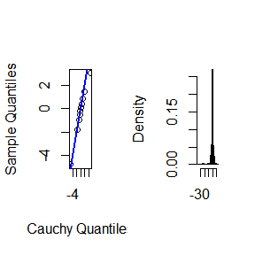

```r
set.seed(21068)
f <- function(x) {1/(pi*(1+x^2))}

m <- 10000
mu <- 0
sigma <- 1
x <- numeric(m)
x[1] <- rnorm(1, mu, sigma)
u <- runif(m)

for (i in 2:m) {
  xt <- x[i-1]
  y <- rnorm(1, xt, sigma)
  r1 <- f(y) * dnorm(xt, y, sigma)
  r2 <- f(xt) * dnorm(y, xt, sigma)
  r <- r1 / r2
  if (u[i] <= r) x[i] <- y else
      x[i] <- xt
}

b <- 1001      #discard the burn-in sample
y <- x[b:m]
a <- ppoints(10)
QR <- qt(a, df=1)  #quantiles of Cauchy
Q <- quantile(x, a)

par(mfrow=c(1, 2))
qqplot(QR, Q, main="", xlab="Cauchy Quantiles", ylab="Sample Quantiles")
abline(0, 1, col='blue', lwd=2)
hist(y, breaks="scott", main="", xlab="", freq=FALSE)
lines(QR, f(QR))
```

## Exercise 9.8

This example appears in $[40]$. Consider the bivariate density
$$f(x, y) \propto \dbinom{n}{k} y^{x+a−1}(1 − y)^{n−x+b−1}, x = 0, 1, \ldots , n, 0 \leq y \leq 1.$$
It can be shown that for fixed $a, b, n,$ the conditional distributions are Binomial$(n, y)$ and Beta$(x+a, n−x+b)$. Use the Gibbs sampler to generate a chain with target joint density $f(x, y)$.

### Solution

Given $a=b=1,n=25$,$f(x_1|x_2)\sim binom(n,x_2),f(x_2|x_1)\sim beta(x_1+a,n-x_1+b)$

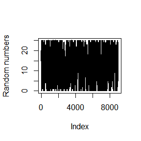

```r
set.seed(21068)
N <- 10000
burn <- 1000
X <- matrix(0, N, 2)
a<- b <- 1
n <- 25
X[1,1] <- rbinom(1, n, 0.5)  #initialize
X[1,2] <- rbeta(1, 50, 50)   #initialize

###### generate the chain #####

for (i in 2:N) {
  x2 <- X[i-1, 2]
  X[i, 1] <- rbinom(1, n, x2)
  x1 <- X[i, 1]
  X[i, 2] <- rbeta(1, x1+a, n-x1+b)
}

b <- burn + 1
x <- X[b:N, ]

#par(mfrow=c(1, 2))
plot(x[,1],type='l',col=1,lwd=2,xlab='Index',ylab='Random numbers')
```

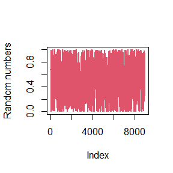

```r
plot(x[,2],type='l',col=2,lwd=2,xlab='Index',ylab='Random numbers')
```

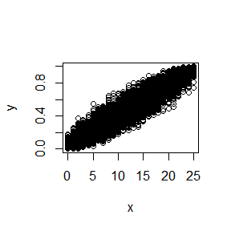

```r
plot(X[,1],X[,2],xlab = "x",ylab = "y")
```

## Problem 3

For each of the above exercise, use the Gelman-Rubin method to monitor convergence of the chain, and run the chain until it converges approximately to the target distribution according to $\hat R < 1.2$.

### Solution

**9.3**

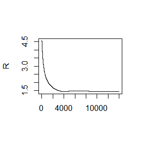

```r
Gelman.Rubin <- function(psi) {
    psi <- as.matrix(psi)
    n <- ncol(psi)
    k <- nrow(psi)

    psi.means <- rowMeans(psi)     #row means
    B <- n * var(psi.means)        #between variance est.
    psi.w <- apply(psi, 1, "var")  #within variances
    W <- mean(psi.w)               #within est.
    v.hat <- W*(n-1)/n + (B/n)     #upper variance est.
    r.hat <- v.hat / W             #G-R statistic
    return(r.hat)
}

f <- function(x) {1/(pi*(1+x^2))}

cauthy.chain <- function(sigma, N, X1) {
    x <- rep(0, N)
    x[1] <- rnorm(1, X1, sigma)
    u <- runif(N)

    for (i in 2:N) {
       xt <- x[i-1]
       y <- rnorm(1, xt, sigma)     #candidate point
       r1 <- f(y) * dnorm(xt, y, sigma)
       r2 <- f(xt) * dnorm(y, xt, sigma)
       r <- r1 / r2
       if (u[i] <= r) x[i] <- y else
            x[i] <- xt
       }
    return(x)
}

sigma <- 1      #parameter of proposal distribution
k <- 4          #number of chains to generate
n <- 15000      #length of chains
b <- 1000       #burn-in length

x0 <- c(-10, -5, 5, 10)

set.seed(123)
X <- matrix(0, nrow=k, ncol=n)
for (i in 1:k)
   X[i, ] <- cauthy.chain(sigma, n, x0[i])

psi <- t(apply(X, 1, cumsum))
for (i in 1:nrow(psi))
    psi[i, ] <- psi[i, ] / (1:ncol(psi))

rhat <- rep(0, n)
for (j in (b+1):n)
  rhat[j] <- Gelman.Rubin(psi[,1:j])
plot(rhat[(b+1):n], type="l", xlab="", ylab="R")
abline(h=1.2, lty=2)
```

**9.8**

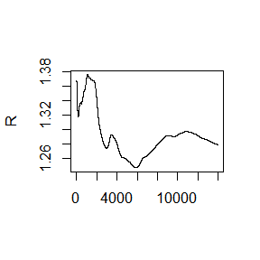

```r
Gelman.Rubin <- function(psi) {
    psi <- as.matrix(psi)
    n <- ncol(psi)
    k <- nrow(psi)

    psi.means <- rowMeans(psi)     #row means
    B <- n * var(psi.means)        #between variance est.
    psi.w <- apply(psi, 1, "var")  #within variances
    W <- mean(psi.w)               #within est.
    v.hat <- W*(n-1)/n + (B/n)     #upper variance est.
    r.hat <- v.hat / W             #G-R statistic
    return(r.hat)
}

binombeta.chain <- function(N, p, alpha, beta, n, a, b) {
    X <- matrix(0, N, 2)
    X[1,1] <- rbinom(1, n, p)
    X[1,2] <- rbeta(1, alpha, beta)

    for (i in 2:N) {
       x2 <- X[i-1, 2]
       X[i, 1] <- rbinom(1, n, x2)
       x1 <- X[i, 1]
       X[i, 2] <- rbeta(1, x1+a, n-x1+b)
    }
    return(X)
}

k <- 4          #number of chains to generate
m <- 15000      #length of chains
burn <- 1000    #burn-in length
n <- 100
a <- b <- 1

X0 <- matrix(c(0.2, 0.4, 0.6, 0.8, 20, 40, 60, 80, 80, 60, 40, 20), 4, 3)

set.seed(1234)
X <- matrix(0, nrow=k, ncol=m)
Y <- matrix(0, nrow=k, ncol=m)
for (i in 1:k){
  Z <- binombeta.chain(m, X0[i,1], X0[i,2], X0[i,3], n, a, b)
  X[i, ] <- Z[ ,1]
  Y[i, ] <- Z[ ,2]
}

psi <- t(apply(X, 1, cumsum))
for (i in 1:nrow(psi))
    psi[i, ] <- psi[i, ] / (1:ncol(psi))

rhat <- rep(0, m)
for (j in (burn+1):m)
  rhat[j] <- Gelman.Rubin(psi[,1:j])
plot(rhat[(burn+1):m], type="l", xlab="", ylab="R")
abline(h=1.2, lty=2)
```

[figure not shown]

```r
psj <- t(apply(Y, 1, cumsum))
for (i in 1:nrow(psj))
    psj[i, ] <- psj[i, ] / (1:ncol(psj))

rhat <- rep(0, m)
for (j in (burn+1):m)
  rhat[j] <- Gelman.Rubin(psj[,1:j])
plot(rhat[(burn+1):m], type="l", xlab="", ylab="R")
abline(h=1.2, lty=2)
```

## Exercise 11.3

**(a)** Write a function to compute the $k^{th}$ term in
$$\sum_{k=0}^{\infty} \frac{(-1)^k}{k!2^k}\frac{\|a\|^{2k+2}}{(2k+1)(2k+2)}\frac{\Gamma\big(\frac{d+1}{2}\big)\Gamma\big(k+\frac{3}{2}\big)}{\Gamma\big(k+\frac{d}{2}+1\big)}$$
where $d \geq 1$ is an integer, $a$ is a vector in $R^d$, and $\|\cdot\|$ denotes the Euclidean norm. Perform the arithmetic so that the coefficients can be computed for (almost) arbitrarily large $k$ and $d$. (This sum converges for all $a \in R^d$).

**(b)** Modify the function so that it computes and returns the sum.

**(c)** Evaluate the sum when $a = (1, 2)^T$ .

### Solution

**(a)**

Set $A_k = \frac{(-1)^k}{k!2^k}\frac{\|a\|^{2k+2}}{(2k+1)(2k+2)}\frac{\Gamma\big(\frac{d+1}{2}\big)\Gamma\big(k+\frac{3}{2}\big)}{\Gamma\big(k+\frac{d}{2}+1\big)}$.

The $k^{th}$ term in the formula is $A_{k-1}$, but the function is similar.So it is OK to write the function to compute the $A_k$.

```r
vector_length <- function(x) {
   temp <- 0
   for (i in 1: length(x)) {
         temp <- temp + x[i]^2
    }
    vlength <- sqrt(temp)
    return(vlength)
}

A_k <- function(k, x) {
  d <- length(x)
  a <- (-1/2)^k/factorial(k)
  b <- exp(lgamma((d+1)/2) + lgamma(k+3/2) - lgamma(k+d/2+1))
  c <- vector_length(x)
  e <- (c^(2*k+2))/((2*k+1)*(2*k+2))
  f <- a * e * b
  return(f)
}
```

**(b)**

The function is to compute $\sum_{k=0}^{\infty} A_k$.

```r
aksum <- function(x) {
  aksum <- A_k(0, x)
  i <- 1
  while (abs(A_k(i, x) - A_k(i-1, x)) > 1e-1000) {
      aksum <- aksum + A_k(i, x)
      i = i + 1
  }
  return(list(m=aksum, k=i))
}
```

**(c)**

```r
x <- c(1, 2)
aksum(x)$m
```

```
## [1] 1.532164
```

## Exercise 11.5

Write a function to solve the equation
$$\frac{2\Gamma\big(\frac{k}{2}\big)}{\sqrt{\pi(k-1)}\Gamma\big(\frac{k-1}{2}\big)}\int_0^{c_{k-1}}{(1+\frac{u^2}{k-1})^{-k/2}}du
\\=\frac{2\Gamma\big(\frac{k+1}{2}\big)}{\sqrt{\pi k}\Gamma\big(\frac{k}{2}\big)}\int_0^{c_k}{(1+\frac{u^2}{k})^{-(k+1)/2}}du$$
for $a$, where
$$c_k=\sqrt{\frac{a^2 k}{k+1-a^2}}$$
Compare the solutions with the points $A(k)$ in Exercise 11.4.

### Solution

Let
$$T_{k-1}(a)=\frac{2\Gamma\big(\frac{k}{2}\big)}{\sqrt{\pi(k-1)}\Gamma\big(\frac{k-1}{2}\big)}\int_0^{c_{k-1}}{(1+\frac{u^2}{k-1})^{-k/2}}du=P(0<t(k-1)<c_{k-1})=P(t(k-1)<c_{k-1})-\frac{1}{2} \\T_k(a)=\frac{2\Gamma\big(\frac{k+1}{2}\big)}{\sqrt{\pi k}\Gamma\big(\frac{k}{2}\big)}\int_0^{c_k}{(1+\frac{u^2}{k})^{-(k+1)/2}}du=P(0<t(k)<c_{k})=P(t(k)<c_{k})-\frac{1}{2}$$

We can see $T_{k-1}(a)=1/2-S_{k-1}(a),T_{k}(a)=1/2-S_{k}(a)$.

So $T_{k-1}=T_{k} \Leftrightarrow S_{k-1}=S_k$.

```r
k=c(4:25,100,500,1000)
solution <- numeric(25)

for (i in 1:length(k)) {
  solution[i]=uniroot(
    function(a) {pt(sqrt(a^2*(k[i]-1)/(k[i]-a^2)),df=k[i]-1)-pt(sqrt(a^2*(k[i])/(k[i]+1-a^2)),df=k[i])},
     c(1e-4, sqrt(k[i])-1e-4))$root
}

x <- cbind(k, solution)
knitr::kable(x, col.names=c("k","solution"))
```

| k | solution |
| --- | --- |
| 4 | 1.492103 |
| 5 | 1.533549 |
| 6 | 1.562768 |
| 7 | 1.584421 |
| 8 | 1.601192 |
| 9 | 1.614517 |
| 10 | 1.625391 |
| 11 | 1.634409 |
| 12 | 1.642004 |
| 13 | 1.648565 |
| 14 | 1.654167 |
| 15 | 1.659099 |
| 16 | 1.663452 |
| 17 | 1.667288 |
| 18 | 1.670736 |
| 19 | 1.673840 |
| 20 | 1.676588 |
| 21 | 1.679139 |
| 22 | 1.681461 |
| 23 | 4.795731 |
| 24 | 4.898879 |
| 25 | 4.999900 |
| 100 | 9.999900 |
| 500 | 22.360580 |
| 1000 | 31.622677 |

## Problem 3

Suppose $T1, \dots, Tn$ are $i.i.d.$ samples drawn from the exponential distribution with expectation $\lambda$. Those values greater than $\tau$ are not observed due to right censorship, so that the observed values are $Y_i = T_iI(T_i \leq \tau ) + \tau I(T_i > \tau), i = 1, \dots, n.$ Suppose $\tau = 1$ and the observed $Y_i$ values are as follows:
$$0.54, 0.48, 0.33, 0.43, 1.00, 1.00, 0.91, 1.00, 0.21, 0.85$$
Use the $E-M$ algorithm to estimate $\lambda$, compare your result with the observed data $MLE$ (note: $Y_i$ follows a mixture distribution).

### Solution

**Observed data MLE**

Suppose the number of observed data is $n$,and the number of data which is smaller than $\tau$ is $r$.We set $x_1,\dots,x_r \leq \tau,x_{r+1},\dots,x_n>\tau$.Then the likelihood function is
$$L_n(x_1,x_2,\dots,x_r,x_{r+1},\dots,x_n;\lambda)=\frac{n!}{(n-r)!}\prod_{i=1}^{r}(\lambda e^{-\lambda x_i})(e^{-\lambda \tau})^{n-r}
\\\Rightarrow logL_n(x_1,x_2,\dots,x_r;\lambda)=log(\frac{n!}{(n-r)!})+rlog\lambda-\lambda(\sum_{i=1}^rx_i+(n-r)\tau)
\\\Rightarrow \hat{\lambda}=\frac{r}{\sum_{i=1}^rx_i+(n-r)\tau}$$

In this case ,$r=7,n=10,\tau=1$,so the estimated value is $28/27$

```r
y <- c(0.54, 0.48, 0.33, 0.43, 1.00, 1.00, 0.91, 1.00, 0.21, 0.85)
n <- length(y)
tau <- 1
r <- length(which(y < tau))

mlogL <- function(lambda=1) {
  return(-log(factorial(n)/factorial(n-r)) - r*log(lambda) + lambda*(sum(y)))
}

library(stats4)
L.MLE <- mle(mlogL)
L.MLE
```

```
##
## Call:
## mle(minuslogl = mlogL)
##
## Coefficients:
##   lambda
## 1.037039
```

**Complete data likelihood**

**E-step:**

$$L_c(x_1,x_2,\dots,x_n;\lambda)=\prod_{i=1}^{n}(\lambda e^{-\lambda x_i})=\lambda ^{n}e^{-\lambda\sum_{i=1}^nx_i}
\\\Rightarrow logL_c(x_1,x_2,\dots,x_n;\lambda)=nlog\lambda-\lambda\sum_{i=1}^nx_i$$
$$E_{\lambda_0}[logL_c|x_1,\dots,x_r,x_{r+1},\dots,x_n]=nlog\lambda-\lambda\sum_{i=1}^rx_i-\lambda\sum_{i=r+1}^nE_{\lambda_0}[x_i|x_i> \tau]=nlog\lambda-\lambda\sum_{i=1}^rx_i-\lambda(n-r)(\frac{1}{\lambda_0}+\tau)$$
where
$$E_{\lambda_0}[x_i|x_i>\tau]=\int_{\tau}^{\infty}{xe^{-\lambda_0(x-\tau)}}dx=\frac{1}{\lambda_0}+\tau$$

**M-step:**

$$\lambda_1=argmaxE_{\lambda_0}[logL_c]=\frac{n}{\sum_{i=1}^rx_i+(n-r)(\frac{1}{\lambda_0}+\tau)}
\\\Rightarrow\lambda_{\infty}=\frac{n}{\sum_{i=1}^rx_i+(n-r)(\frac{1}{\lambda_\infty}+\tau)}
\\\Rightarrow\hat{\lambda}=\frac{r}{\sum_{i=1}^rx_i+(n-r)\tau}$$

```r
y <- c(0.54, 0.48, 0.33, 0.43, 1.00, 1.00, 0.91, 1.00, 0.21, 0.85)

L <- 1
N <- 10000
n <- length(y)
tau <- 1

for (i in 1:N) {
      r <- length(which(y < tau))
      L.old <- L
      L <- n/(sum(y) + (n-r)*(1/L.old))

      if (abs((L - L.old)/L.old) < 1e-8) break
}
cat("L.EM =", L)
```

```
## L.EM = 1.037037
```

## Exercise 11.1.2.1

1. Why are the following two invocations of lapply() equivalent?

```r
trims <- c(0, 0.1, 0.2, 0.5)
x <- rcauchy(100)
lapply(trims, function(trim) mean(x, trim = trim))
```

```
## [[1]]
## [1] 4.158182
##
## [[2]]
## [1] 0.269774
##
## [[3]]
## [1] 0.1436236
##
## [[4]]
## [1] 0.2697976
```

```r
lapply(trims, mean, x = x)
```

```
## [[1]]
## [1] 4.158182
##
## [[2]]
## [1] 0.269774
##
## [[3]]
## [1] 0.1436236
##
## [[4]]
## [1] 0.2697976
```

### Answer

In the first statement each element of `trims` is explicitly supplied to `mean()`’s second argument.

In the latter statement this happens via positional matching, since `mean()`’s first argument is supplied via name in `lapply()`’s third argument (`...`).

## Exercise 11.1.2.5

5. For each model in the previous two exercises, extract R2 using the function below.

```r
rsq <- function(mod) summary(mod)$r.squared
```

### Answer

**For the models in exercise 3:**

```r
formulas <- list(
  mpg ~ disp,
  mpg ~ I(1 / disp),
  mpg ~ disp + wt,
  mpg ~ I(1 / disp) + wt
)


a <- lapply(formulas, function(x) lm(formula = x, data = mtcars))

f <- vector("list", length(formulas))
for (i in seq_along(formulas)){
  f[[i]] <- lm(formulas[[i]], data = mtcars)
}

sapply(a, rsq)
```

```
## [1] 0.7183433 0.8596865 0.7809306 0.8838038
```

```r
sapply(f, rsq)
```

```
## [1] 0.7183433 0.8596865 0.7809306 0.8838038
```

**the models in exercise 4:**

```r
bootstraps <- lapply(1:10, function(i) {
  rows <- sample(1:nrow(mtcars), rep = TRUE)
  mtcars[rows, ]
})


a <- lapply(seq_along(bootstraps), function(i) {lm(mpg ~ disp,data=bootstraps[[i]])})


f <- vector("list", length(bootstraps))
for (i in seq_along(bootstraps)){
  f[[i]] <- lm(mpg ~ disp, data = bootstraps[[i]])
}

sapply(a, rsq)
```

```
##  [1] 0.8150775 0.6557605 0.6955273 0.8206330 0.7975696 0.5995222 0.7319104
##  [8] 0.7509501 0.6917722 0.7046225
```

```r
sapply(f, rsq)
```

```
##  [1] 0.8150775 0.6557605 0.6955273 0.8206330 0.7975696 0.5995222 0.7319104
##  [8] 0.7509501 0.6917722 0.7046225
```

## Exercise 11.2.5.1

1. Use $vapply()$ to:
1. Compute the standard deviation of every column in a numeric data frame.
2. Compute the standard deviation of every numeric column in a mixed data frame. (Hint: you’ll need to use $vapply()$ twice.)

### Answer

As a numeric `data.frame` we choose `cars`:

```r
vapply(cars, sd, numeric(1))
```

```
##     speed      dist
##  5.287644 25.769377
```

And as a mixed `data.frame` we choose `mtcars`:

```r
vapply(mtcars[vapply(mtcars, is.numeric, logical(1))], sd, numeric(1))
```

```
##         mpg         cyl        disp          hp        drat          wt
##   6.0269481   1.7859216 123.9386938  68.5628685   0.5346787   0.9784574
##        qsec          vs          am        gear        carb
##   1.7869432   0.5040161   0.4989909   0.7378041   1.6152000
```

## Exercise 11.2.5.7

7. Implement $mcsapply()$, a multicore version of $sapply()$. Can you implement $mcvapply()$, a parallel version of $vapply()$? Why or why not?

### Answer

Sorry,I don not know how to solve this question.

## Problem

**Exercise 9.8**

This example appears in $[40]$. Consider the bivariate density
$$f(x, y) \propto \dbinom{n}{k} y^{x+a−1}(1 − y)^{n−x+b−1}, x = 0, 1, \ldots , n, 0 \leq y \leq 1.$$
It can be shown that for fixed $a, b, n,$ the conditional distributions are Binomial$(n, y)$ and Beta$(x+a, n−x+b)$. Use the Gibbs sampler to generate a chain with target joint density $f(x, y)$.

**(1)**Write an Rcpp function for Exercise 9.8 (page 278, Statistical Computing with R).

**(2)**Compare the corresponding generated random numbers with pure R language using the function “qqplot”.

**(3)**Compare the computation time of the two functions with the function “microbenchmark”.

Comments your results.

## Answer

**(1)**

R function:

```r
GibbsR <- function(N, x0, n, a, b){
  X <- matrix(0, N, 2)
  X[1,] <- x0
  for(i in 2:N){
    x2 <- X[i-1, 2]
    X[i, 1] <- rbinom(1, n, x2)
    x1 <- X[i, 1]
    X[i, 2] <- rbeta(1, x1+a, n-x1+b)
  }
  return(X)
}
```

Rcpp function:

```r
library(Rcpp)

cppFunction('NumericMatrix GibbsC(int N, NumericVector x0, int n, double a, double b) {
            NumericMatrix X(N,2);
            X(0, 0) = x0[1];
            X(0, 1) = x0[2];
            for(int i = 1; i < N; i++)
            {
              double x2 = X(i-1, 1);
              X(i, 0) = rbinom(1, n, x2)[0];
              double x1 = X(i, 0);
              X(i, 1) = rbeta(1, x1+a, n-x1+b)[0];
            }
            return X;
}')
```

**(2)**

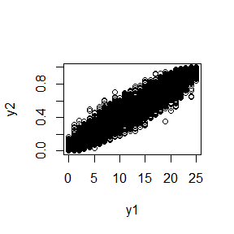

```r
set.seed(21068)
N <- 10000
burn <- 1000
a<- b <- 1
n <- 25
x0 <- c(0, 0.5)

X<-GibbsR(N, x0, n, a, b)
Y<-GibbsC(N, x0, n, a, b)

#par(mfrow = c(2, 2))
plot(Y[1001:N,1],Y[1001:N,2],xlab = "y1",ylab = "y2")
```

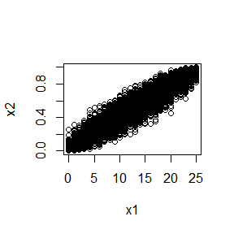

```r
plot(X[1001:N,1],X[1001:N,2],xlab = "x1",ylab = "x2")
```

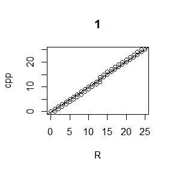

```r
qqplot(X[1001:N,1],Y[1001:N,1],xlab='R',ylab='cpp',main='1')
abline(0, 1)
```

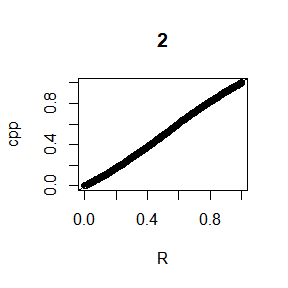

```r
qqplot(X[1001:N,2],Y[1001:N,2],xlab='R',ylab='cpp',main='2')
abline(0, 1)
```

The qqplot of random Numbers obtained by Rcpp and R is relatively close .

**(3)**

```r
library(microbenchmark)

ts <- microbenchmark(R=GibbsR(N, x0, n, a, b),Rcpp=GibbsC(N, x0, n, a, b))
print(summary(ts)[, c(1,3,5,6)])
```

```
##   expr      lq   median       uq
## 1    R 32.2550 34.15105 36.84475
## 2 Rcpp  2.6617  2.75535  2.89495
```

The calculation time of Rcpp is significantly less than R, which indicates that Rcpp can effectively improve our calculation efficiency.